# Exploratory Analysis (Blowdown 2019)

Eduardo Q Marques

## Load and resume field data

```r
library(tidyverse)
library(reshape2)
library(ggplot2)

#Load data
setwd('C:/Users/Eduardo Q Marques/Documents/My Jobs/Doutorado/Deposito/Banco de Dados Tanguro/Area1-plot/Campo vento')

df = read.csv("storm_data_full_C.csv", sep = ",")

#Resume data
df = df[,c(3,4,5,6,7,8,9,10,11,12)]
df$nt = 1
colnames(df) = c("Specie","Treatment","Line","Transect","Condition","Alt_Scar","Wind?","Direction","Damage","Alt_Broken","Number_of_Trees")


#Summary information
summary(df)
```

```
##              Specie      Treatment        Line          Transect
##  tachi_do_campo : 30   B1yr   :120   Min.   : 1.00          :98
##  breu_aroeira   : 18   B3yr   : 69   1st Qu.: 9.00   f      :56
##  mangabinha     : 17   Control:108   Median :18.50   k      :49
##  louro_abacate  : 16                 Mean   :17.73   c      :26
##  canela_de_veado: 15                 3rd Qu.:25.75   ab     :24
##  tatapiririca   : 15                 Max.   :30.00   p      :24
##  (Other)        :186                 NA's   :199     (Other):20
##    Condition      Alt_Scar     Wind?     Direction          Damage
##  No Scar:241   Min.   :0.100   n: 47   Min.   :  0.0   Broken  :151
##  Scar   : 56   1st Qu.:0.500   s:250   1st Qu.:290.0   Crown   : 41
##                Median :0.950           Median :318.0   Uprooted:105
##                Mean   :1.098           Mean   :279.7
##                3rd Qu.:1.500           3rd Qu.:339.8
##                Max.   :4.500           Max.   :359.0
##                NA's   :241             NA's   :83
##    Alt_Broken   Number_of_Trees
##  Min.   : 0.1   Min.   :1
##  1st Qu.: 1.5   1st Qu.:1
##  Median : 3.5   Median :1
##  Mean   : 4.3   Mean   :1
##  3rd Qu.: 6.0   3rd Qu.:1
##  Max.   :15.0   Max.   :1
##  NA's   :146
```

## Overview

Basic information by blowdown:  
Most of the damage occurred in treatment B1yr (120), followed by Control (108) and B3yr (69). Most damage types are Broken (151), followed by Uprooted (105) and Crown damage (41).  
When looking for some type of damage in each plot:  
All Broken treatment is the type of damage most serious, followed by Uprooted and Crown. But the biggest difference in the type of damage is in the B3yr.  
About the direction of the tree fell, most of the trees fell at 339 °, in the northwest direction. We need to see the wind direction to make the comparison.

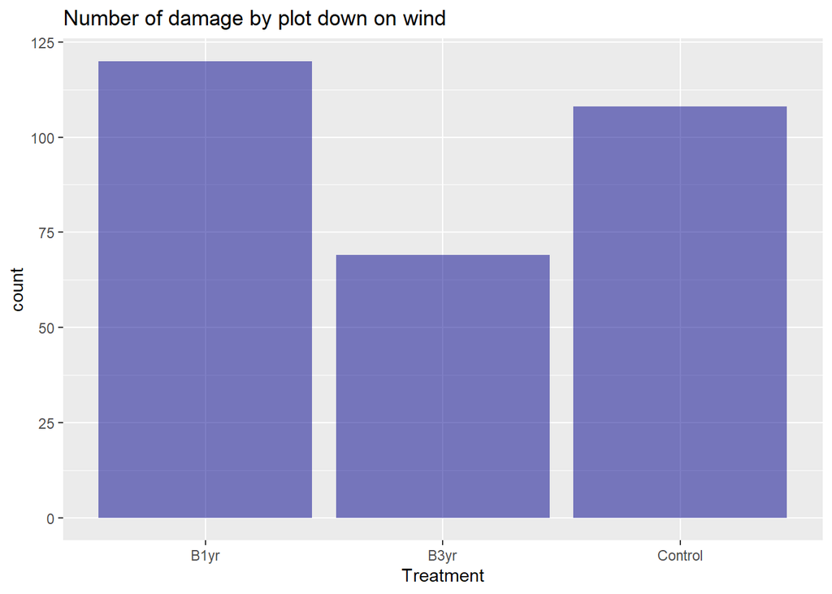

```r
#Damage by plot down on wind
ggplot(df, aes(x=Treatment))+
  geom_bar(position = "dodge", fill = "darkblue", alpha = 0.5)+
  ggtitle("Number of damage by plot down on wind")
```

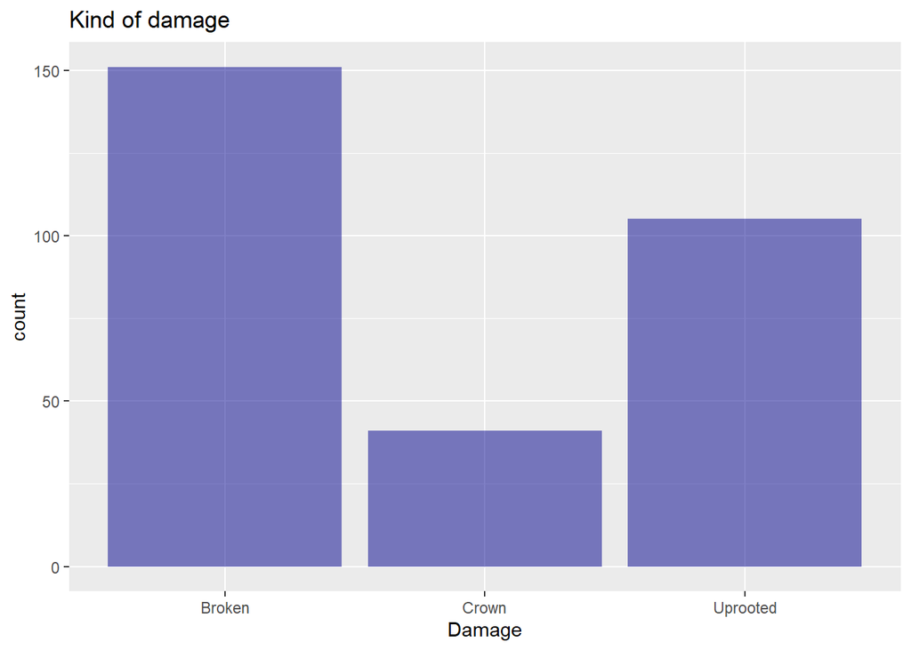

```r
#Kind of damage data
ggplot(df, aes(x=Damage, fill = Treatment))+
  geom_bar(position = "dodge", fill = "darkblue", alpha = 0.5)+
  ggtitle("Kind of damage")
```

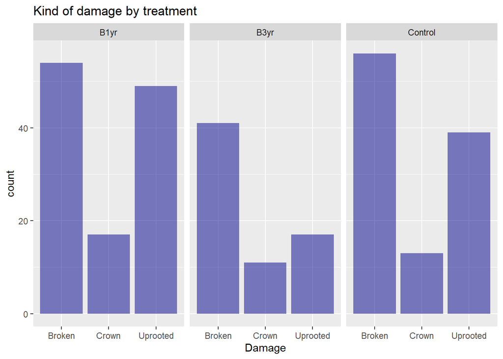

```r
#Kind of damage by treatment
ggplot(df, aes(x=Damage))+
  geom_bar(position = "dodge", fill = "darkblue", alpha = 0.5)+
  facet_wrap(~Treatment)+
  ggtitle("Kind of damage by treatment")
```

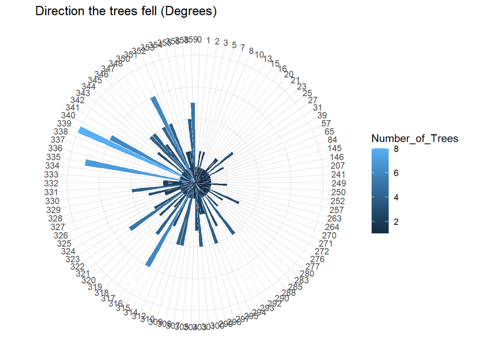

```r
#Fall direction
wind = df %>%
  group_by(Direction) %>%
  summarise(Number_of_Trees = sum(Number_of_Trees)) %>%
  na.omit()
wind$Direction = as.factor(wind$Direction)

ggplot(wind, aes(x=Direction, y = Number_of_Trees, fill = Number_of_Trees))+
  geom_bar(stat="identity")+
  theme_minimal()+
  theme(
    axis.text.y = element_blank(),
    axis.title = element_blank())+
  coord_polar(start = 0)+
  ggtitle("Direction the trees fell (Degrees)")
```